# Airway RNA-seq: Dexamethasone vs Untreated (DESeq2)

Author

Generated with Claude Code

Published

August 5, 2026

```r
# --- Packages -------------------------------------------------------------
# If any of these are missing, install once (uncomment and run in a console):
#
#   install.packages(c("tidyverse", "pheatmap", "RColorBrewer"))
#   if (!requireNamespace("BiocManager", quietly = TRUE)) install.packages("BiocManager")
#   BiocManager::install(c("DESeq2", "apeglm", "EnhancedVolcano"))
#
# The document renders end-to-end once these are available.

suppressPackageStartupMessages({
  library(DESeq2)
  library(tidyverse)
  library(pheatmap)
  library(RColorBrewer)
})

# EnhancedVolcano is optional; fall back to a ggplot volcano if unavailable.
have_enhanced_volcano <- requireNamespace("EnhancedVolcano", quietly = TRUE)

# --- Paths ----------------------------------------------------------------
# Resolve the repository root robustly by searching upward from the working
# directory until we find the data/ directory. This keeps the document working
# whether it is rendered from the repo root or from a subfolder.
find_repo_root <- function(start = getwd(), marker = "data") {
  dir <- normalizePath(start, mustWork = FALSE)
  for (i in 1:6) {
    if (dir.exists(file.path(dir, marker)) &&
        file.exists(file.path(dir, marker, "experiment_table.csv"))) {
      return(dir)
    }
    parent <- dirname(dir)
    if (identical(parent, dir)) break
    dir <- parent
  }
  stop("Could not locate the repo root (a folder containing data/experiment_table.csv).")
}

here_root    <- find_repo_root()
counts_path  <- file.path(here_root, "data", "rsem.merged.gene_counts.tsv")
samples_path <- file.path(here_root, "data", "experiment_table.csv")

results_dir <- file.path(here_root, "results")
dir.create(results_dir, showWarnings = FALSE, recursive = TRUE)

stopifnot(file.exists(counts_path), file.exists(samples_path))

# Analysis parameters
alpha_fdr        <- 0.05   # FDR threshold for calling DE genes
min_count        <- 10     # per-sample count floor for pre-filtering
min_samples      <- 4      # genes must clear min_count in >= this many samples
                           # (4 = size of the smallest treatment group)
```

# Overview

This document runs a standard bulk RNA-seq differential-expression analysis on the **airway** dataset: primary human airway smooth muscle cells from four donors (cell lines), each sequenced **Untreated** and treated with **Dexamethasone**.

The design is **paired** — the same donor appears in both conditions — so we block on `cellLine` and test the `treatment` effect:

$$\text{design} = \sim \text{cellLine} + \text{treatment}$$

`Untreated` is the reference level, so a positive log2 fold-change means the gene is **up in Dexamethasone** relative to Untreated.

# Load inputs

```r
# Counts: gene_id, transcript_id(s), then one column per sample (SRA accession).
counts_raw <- readr::read_tsv(counts_path, show_col_types = FALSE)

# Sample sheet: ID (SRA accession), cellLine, treatment.
coldata_raw <- readr::read_csv(samples_path, show_col_types = FALSE)

dim(counts_raw)
```

```
[1] 58735    10
```

```r
coldata_raw
```

| ID | cellLine | treatment |
| --- | --- | --- |
| SRR1039508 | N61311 | Untreated |
| SRR1039509 | N61311 | Dexamethasone |
| SRR1039512 | N052611 | Untreated |
| SRR1039513 | N052611 | Dexamethasone |
| SRR1039516 | N080611 | Untreated |
| SRR1039517 | N080611 | Dexamethasone |
| SRR1039520 | N061011 | Untreated |
| SRR1039521 | N061011 | Dexamethasone |

```r
# Drop non-count columns and set Ensembl gene IDs as rownames.
count_mat <- counts_raw |>
  dplyr::select(-`transcript_id(s)`) |>
  tibble::column_to_rownames("gene_id") |>
  as.matrix()

# Sample sheet as a data frame with row order we control.
coldata <- as.data.frame(coldata_raw)
rownames(coldata) <- coldata$ID
```

# Align samples

The count columns must line up with the sample sheet rows exactly. We reorder the matrix columns to match the sample-sheet `ID` order and then assert equality — if the inputs ever change, this fails loudly instead of producing silently wrong results.

```r
count_mat <- count_mat[, coldata$ID]
stopifnot(identical(colnames(count_mat), coldata$ID))

# Confirm the join is 1:1 over all 8 samples.
stopifnot(ncol(count_mat) == nrow(coldata))
colnames(count_mat)
```

```
[1] "SRR1039508" "SRR1039509" "SRR1039512" "SRR1039513" "SRR1039516"
[6] "SRR1039517" "SRR1039520" "SRR1039521"
```

# Round non-integer RSEM counts

RSEM assigns ambiguous reads probabilistically, so its gene-level counts are **estimates, not integers** (e.g. `284.50`). DESeq2’s negative-binomial model requires integer counts, so we round before building the dataset. (The more principled alternative is `tximport` on the per-sample RSEM files, which are not included in this repository — only the merged gene-level table is.)

```r
# Show that the raw matrix really is non-integer.
any_non_integer <- any(count_mat != round(count_mat))
cat("Matrix contains non-integer values:", any_non_integer, "\n")
```

```
Matrix contains non-integer values: TRUE
```

```r
count_mat <- round(count_mat)
storage.mode(count_mat) <- "integer"

cat("Rounded matrix dimensions:", nrow(count_mat), "genes x",
    ncol(count_mat), "samples\n")
```

```
Rounded matrix dimensions: 58735 genes x 8 samples
```

# Factors and reference level

```r
coldata$cellLine  <- factor(coldata$cellLine)
coldata$treatment <- factor(coldata$treatment)

# Untreated is the baseline; log2FC will read as Dexamethasone-vs-Untreated.
coldata$treatment <- relevel(coldata$treatment, ref = "Untreated")

levels(coldata$treatment)
```

```
[1] "Untreated"     "Dexamethasone"
```

```r
table(coldata$cellLine, coldata$treatment)
```

```
          Untreated Dexamethasone
  N052611         1             1
  N061011         1             1
  N080611         1             1
  N61311          1             1
```

# Build the DESeqDataSet and pre-filter

```r
dds <- DESeqDataSetFromMatrix(
  countData = count_mat,
  colData   = coldata,
  design    = ~ cellLine + treatment
)

# Pre-filter: keep genes with at least `min_count` reads in at least
# `min_samples` samples. This removes the large block of all-zero / very low
# genes before fitting.
keep <- rowSums(counts(dds) >= min_count) >= min_samples
cat("Genes before filtering:", nrow(dds), "\n")
```

```
Genes before filtering: 58735
```

```r
dds  <- dds[keep, ]
cat("Genes after filtering: ", nrow(dds), "\n")
```

```
Genes after filtering:  15478
```

# Run DESeq2

```r
dds <- DESeq(dds)
resultsNames(dds)
```

```
[1] "Intercept"
[2] "cellLine_N061011_vs_N052611"
[3] "cellLine_N080611_vs_N052611"
[4] "cellLine_N61311_vs_N052611"
[5] "treatment_Dexamethasone_vs_Untreated"
```

# Quality control

Variance-stabilising transform, then PCA and a sample-distance heatmap. We expect samples to separate by treatment while pairing by donor (cell line).

```r
vsd <- vst(dds, blind = TRUE)
```

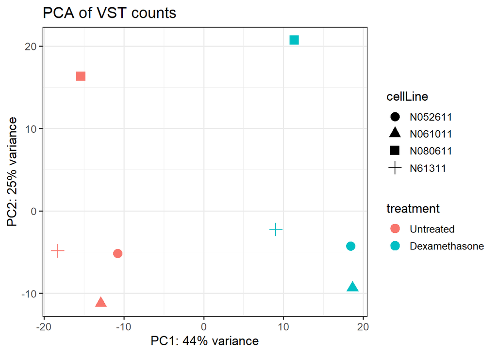

Figure 1: PCA of VST-transformed counts. Colour = treatment, shape = cell line.

```r
pca_df <- plotPCA(vsd, intgroup = c("treatment", "cellLine"), returnData = TRUE)
pct    <- round(100 * attr(pca_df, "percentVar"))

p_pca <- ggplot(pca_df, aes(PC1, PC2, colour = treatment, shape = cellLine)) +
  geom_point(size = 4) +
  labs(
    x = paste0("PC1: ", pct[1], "% variance"),
    y = paste0("PC2: ", pct[2], "% variance"),
    title = "PCA of VST counts"
  ) +
  theme_bw(base_size = 13)

p_pca
ggsave(file.path(results_dir, "pca.png"), p_pca, width = 7, height = 5, dpi = 150)
```

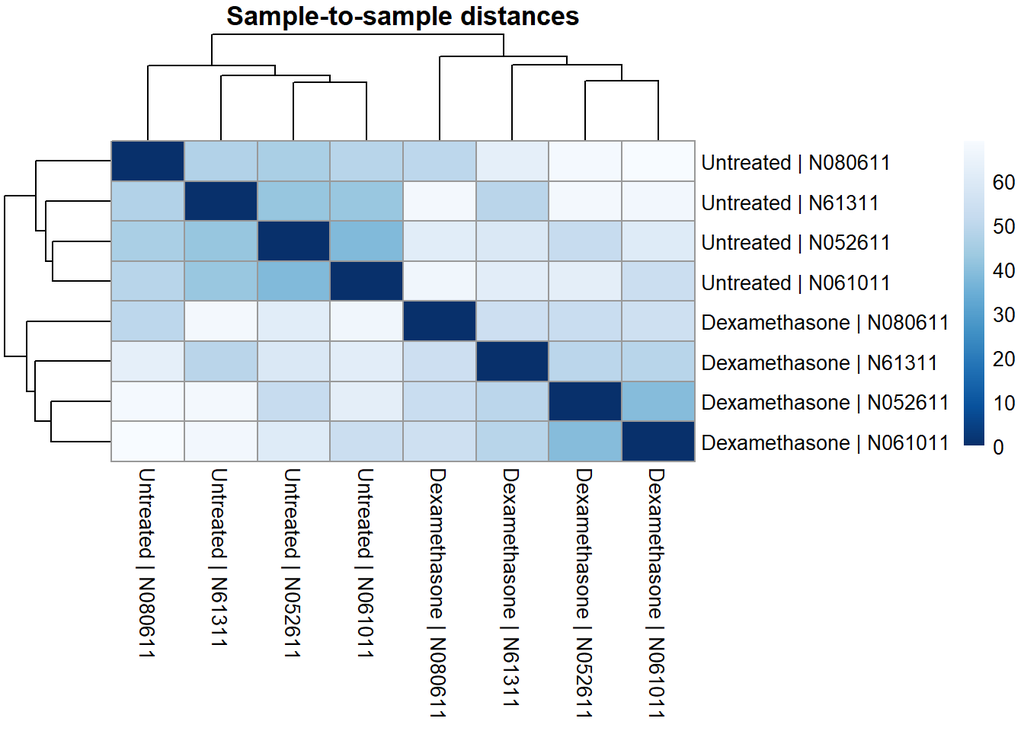

Figure 2: Euclidean distances between samples on VST-transformed counts.

```r
# pheatmap returns a grob invisibly and does not always get captured by knitr
# when also writing to a file. Build it once with silent = TRUE, save the grob
# to PNG explicitly, then grid.draw it so the figure appears inline too.
save_pheatmap_png <- function(ph, filename, width = 7, height = 6, res = 150) {
  png(filename, width = width, height = height, units = "in", res = res)
  grid::grid.newpage()
  grid::grid.draw(ph$gtable)
  invisible(dev.off())
}

sample_dists <- dist(t(assay(vsd)))
dist_mat <- as.matrix(sample_dists)
rownames(dist_mat) <- paste(vsd$treatment, vsd$cellLine, sep = " | ")
colnames(dist_mat) <- rownames(dist_mat)

ph_dist <- pheatmap(
  dist_mat,
  clustering_distance_rows = sample_dists,
  clustering_distance_cols = sample_dists,
  col = colorRampPalette(rev(brewer.pal(9, "Blues")))(255),
  main = "Sample-to-sample distances",
  silent = TRUE
)
save_pheatmap_png(ph_dist, file.path(results_dir, "sample_distance_heatmap.png"),
                  width = 7, height = 6)
grid::grid.newpage()
grid::grid.draw(ph_dist$gtable)  # inline figure
```

# Differential expression results

```r
res <- results(
  dds,
  contrast = c("treatment", "Dexamethasone", "Untreated"),
  alpha = alpha_fdr
)

# Shrunken log2 fold-changes for ranking and plotting.
res_shrunk <- lfcShrink(dds, coef = "treatment_Dexamethasone_vs_Untreated",
                        type = "apeglm")

summary(res)
```

```
out of 15478 with nonzero total read count
adjusted p-value < 0.05
LFC > 0 (up)       : 2189, 14%
LFC < 0 (down)     : 1761, 11%
outliers [1]       : 0, 0%
low counts [2]     : 301, 1.9%
(mean count < 11)
[1] see 'cooksCutoff' argument of ?results
[2] see 'independentFiltering' argument of ?results
```

```r
n_de <- sum(res$padj < alpha_fdr, na.rm = TRUE)
cat("Genes with padj <", alpha_fdr, ":", n_de, "\n")
```

```
Genes with padj < 0.05 : 3950
```

```r
res_df <- as.data.frame(res) |>
  tibble::rownames_to_column("gene_id") |>
  dplyr::arrange(padj)

head(res_df, 15)
```

|  | gene_id | baseMean | log2FoldChange | lfcSE | stat | pvalue | padj |
| --- | --- | --- | --- | --- | --- | --- | --- |
| 1 | ENSG00000152583 | 968.8840 | 4.575127 | 0.18270169 | 25.04151 | 2.160030e-138 | 3.278277e-134 |
| 2 | ENSG00000165995 | 519.8866 | 3.315313 | 0.13479277 | 24.59563 | 1.406845e-133 | 1.067584e-129 |
| 3 | ENSG00000120129 | 3207.5605 | 2.945404 | 0.12150986 | 24.24004 | 8.421693e-130 | 4.260535e-126 |
| 4 | ENSG00000101347 | 13641.7226 | 3.754083 | 0.15853176 | 23.68032 | 5.751762e-124 | 2.182362e-120 |
| 5 | ENSG00000189221 | 2273.8445 | 3.343813 | 0.14248085 | 23.46851 | 8.556707e-122 | 2.597303e-118 |
| 6 | ENSG00000162614 | 5191.7332 | 2.023982 | 0.08789017 | 23.02853 | 2.414193e-117 | 6.106702e-114 |
| 7 | ENSG00000157214 | 2824.9065 | 1.970787 | 0.08564877 | 23.01010 | 3.693290e-117 | 8.007581e-114 |
| 8 | ENSG00000211445 | 11947.3983 | 3.724452 | 0.16880475 | 22.06367 | 7.061650e-108 | 1.339683e-104 |
| 9 | ENSG00000196136 | 2600.1206 | 3.210647 | 0.14602299 | 21.98727 | 3.812516e-107 | 6.429173e-104 |
| 10 | ENSG00000125148 | 3529.1018 | 2.198821 | 0.10600565 | 20.74249 | 1.433177e-95 | 2.175133e-92 |

[output cut: 5 more lines]

# Figures

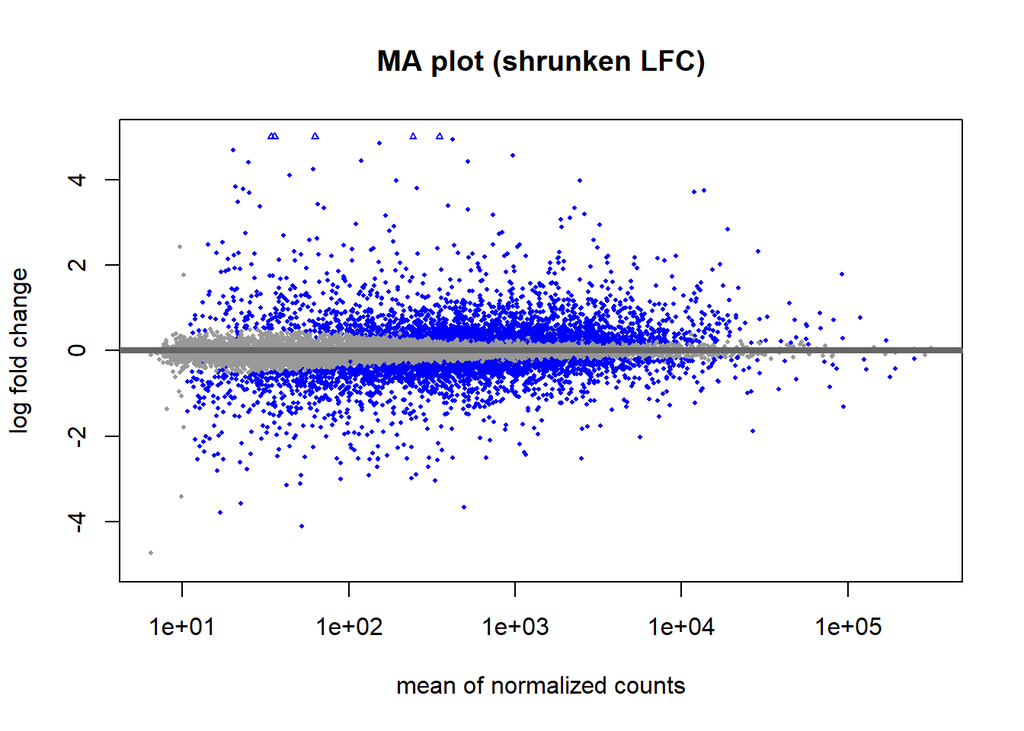

Figure 3: MA plot of shrunken log2 fold-changes (Dexamethasone vs Untreated).

```r
png(file.path(results_dir, "ma_plot.png"), width = 7, height = 5,
    units = "in", res = 150)
plotMA(res_shrunk, ylim = c(-5, 5), main = "MA plot (shrunken LFC)")
invisible(dev.off())

plotMA(res_shrunk, ylim = c(-5, 5), main = "MA plot (shrunken LFC)")
```

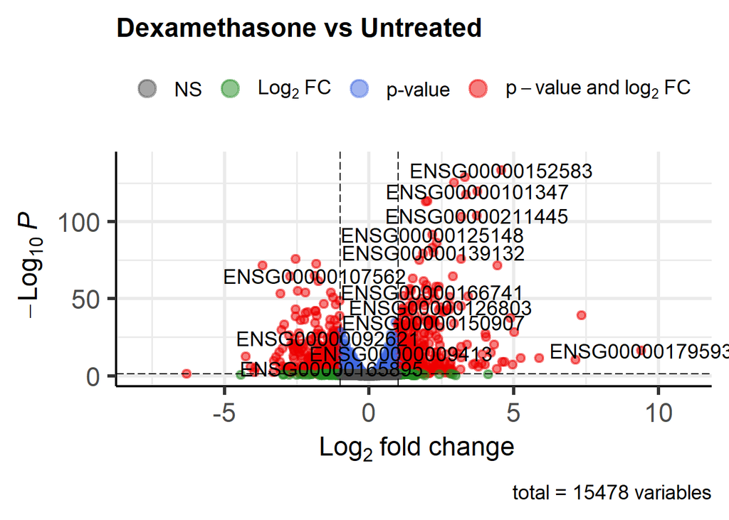

Figure 4: Volcano plot of differential expression.

```r
if (have_enhanced_volcano) {
  p_volcano <- EnhancedVolcano::EnhancedVolcano(
    res_df,
    lab = res_df$gene_id,
    x = "log2FoldChange",
    y = "padj",
    pCutoff = alpha_fdr,
    FCcutoff = 1,
    title = "Dexamethasone vs Untreated",
    subtitle = NULL
  )
} else {
  # ggplot fallback so the document always renders.
  volc_df <- res_df |>
    dplyr::filter(!is.na(padj)) |>
    dplyr::mutate(
      sig = dplyr::case_when(
        padj < alpha_fdr & log2FoldChange >=  1 ~ "Up",
        padj < alpha_fdr & log2FoldChange <= -1 ~ "Down",
        TRUE ~ "NS"
      )
    )
  p_volcano <- ggplot(volc_df,
                      aes(log2FoldChange, -log10(padj), colour = sig)) +
    geom_point(alpha = 0.6, size = 1.4) +
    scale_colour_manual(values = c(Up = "firebrick", Down = "steelblue",
                                   NS = "grey70")) +
    geom_vline(xintercept = c(-1, 1), linetype = "dashed", colour = "grey50") +
    geom_hline(yintercept = -log10(alpha_fdr), linetype = "dashed",
               colour = "grey50") +
    labs(title = "Dexamethasone vs Untreated", colour = NULL) +
    theme_bw(base_size = 13)
}

p_volcano
ggsave(file.path(results_dir, "volcano.png"), p_volcano,
       width = 8, height = 6, dpi = 150)
```

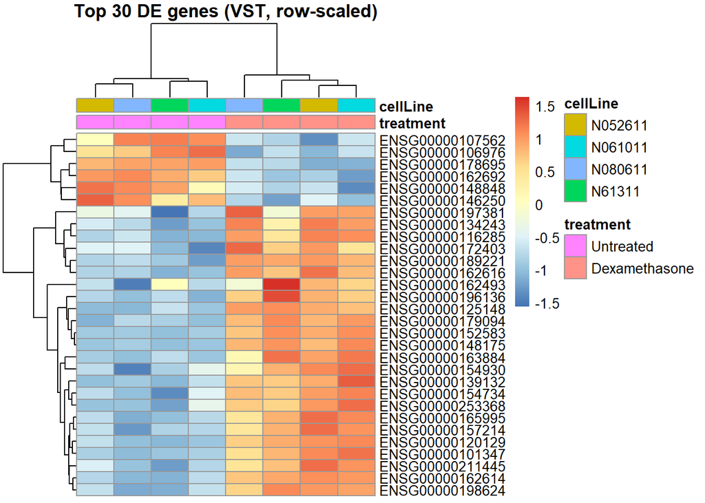

Figure 5: Top 30 DE genes (by adjusted p-value) on VST-transformed counts, row-scaled.

```r
top_genes <- res_df |>
  dplyr::filter(!is.na(padj)) |>
  dplyr::slice_min(padj, n = 30, with_ties = FALSE) |>
  dplyr::pull(gene_id)

mat <- assay(vsd)[top_genes, , drop = FALSE]
mat <- t(scale(t(mat)))  # row-scale (z-score per gene)

annot_col <- as.data.frame(colData(vsd)[, c("treatment", "cellLine")])

ph_top <- pheatmap(
  mat,
  annotation_col = annot_col,
  show_colnames = FALSE,
  main = "Top 30 DE genes (VST, row-scaled)",
  silent = TRUE
)
save_pheatmap_png(ph_top, file.path(results_dir, "top_genes_heatmap.png"),
                  width = 8, height = 8)
grid::grid.newpage()
grid::grid.draw(ph_top$gtable)  # inline figure
```

# Export results

```r
out_csv <- file.path(results_dir, "deseq2_results.csv")
readr::write_csv(res_df, out_csv)
cat("Wrote full results table to:", out_csv, "\n")
```

```
Wrote full results table to: C:\Users\pennb\OneDrive - The Francis Crick Institute\Documents\ClaudeProject\claude_code_demo/results/deseq2_results.csv
```

```r
cat("Figures written to:", results_dir, "\n")
```

```
Figures written to: C:\Users\pennb\OneDrive - The Francis Crick Institute\Documents\ClaudeProject\claude_code_demo/results
```